# mtDNA-CN analysis

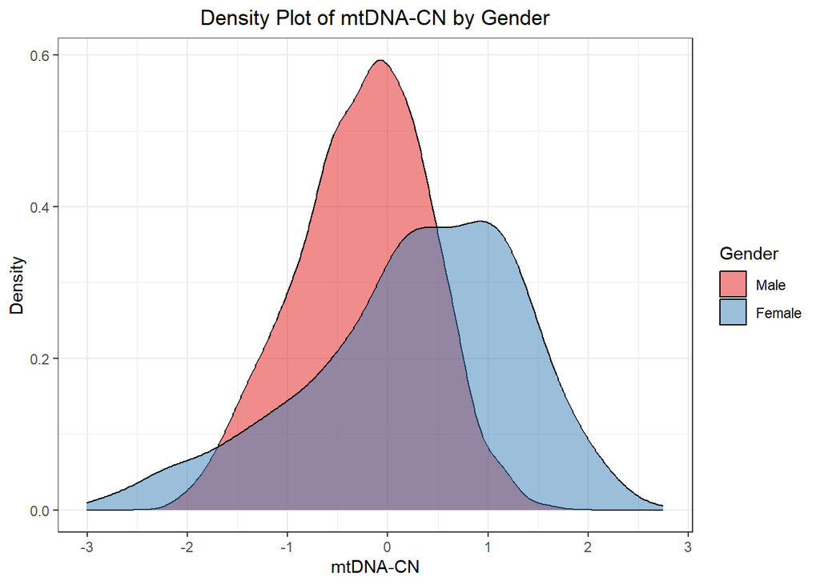

```r
# Density Plot of mtDNA-CN by Gender
ggplot(data, aes(x = mtDNA_CN_INT_residual, fill = factor(Gender))) +
  geom_density(alpha = 0.5) +
  theme_bw() +
  labs(title = "Density Plot of mtDNA-CN by Gender",
       x = "mtDNA-CN",
       y = "Density") +
  theme(plot.title = element_text(hjust = 0.5)) +
   scale_fill_brewer(palette = "Set1", name = "Gender", labels = c("Male", "Female"))
```

```r
# Differences in mtDNA-CN in different gender by group
# Compared to muscle, mtDNA-CN was significantly higher in females than males in Liver using t test and wilcox test
t.test(mtDNA_CN_INT_residual ~ Gender, data = data[data$Group == "Liver",])
```

```
##
##  Welch Two Sample t-test
##
## data:  mtDNA_CN_INT_residual by Gender
## t = -28.833, df = 1016, p-value < 2.2e-16
## alternative hypothesis: true difference in means between group 1 and group 2 is not equal to 0
## 95 percent confidence interval:
##  -1.274732 -1.112276
## sample estimates:
## mean in group 1 mean in group 2
##      -0.2519542       0.9415498
```

```r
wilcox.test(mtDNA_CN_INT_residual ~ Gender, data = data[data$Group == "Liver",])
```

```
##
##  Wilcoxon rank sum test with continuity correction
##
## data:  mtDNA_CN_INT_residual by Gender
## W = 26261, p-value < 2.2e-16
## alternative hypothesis: true location shift is not equal to 0
```

```r
t.test(mtDNA_CN_INT_residual ~ Gender, data = data[data$Group == "Muscle",])
```

```
##
##  Welch Two Sample t-test
##
## data:  mtDNA_CN_INT_residual by Gender
## t = 3.3437, df = 861.76, p-value = 0.0008625
## alternative hypothesis: true difference in means between group 1 and group 2 is not equal to 0
## 95 percent confidence interval:
##  0.07174484 0.27568695
## sample estimates:
## mean in group 1 mean in group 2
##      -0.2606469      -0.4343628
```

```r
wilcox.test(mtDNA_CN_INT_residual ~ Gender, data = data[data$Group == "Muscle",])
```

```
##
##  Wilcoxon rank sum test with continuity correction
##
## data:  mtDNA_CN_INT_residual by Gender
## W = 127115, p-value = 0.05194
## alternative hypothesis: true location shift is not equal to 0
```

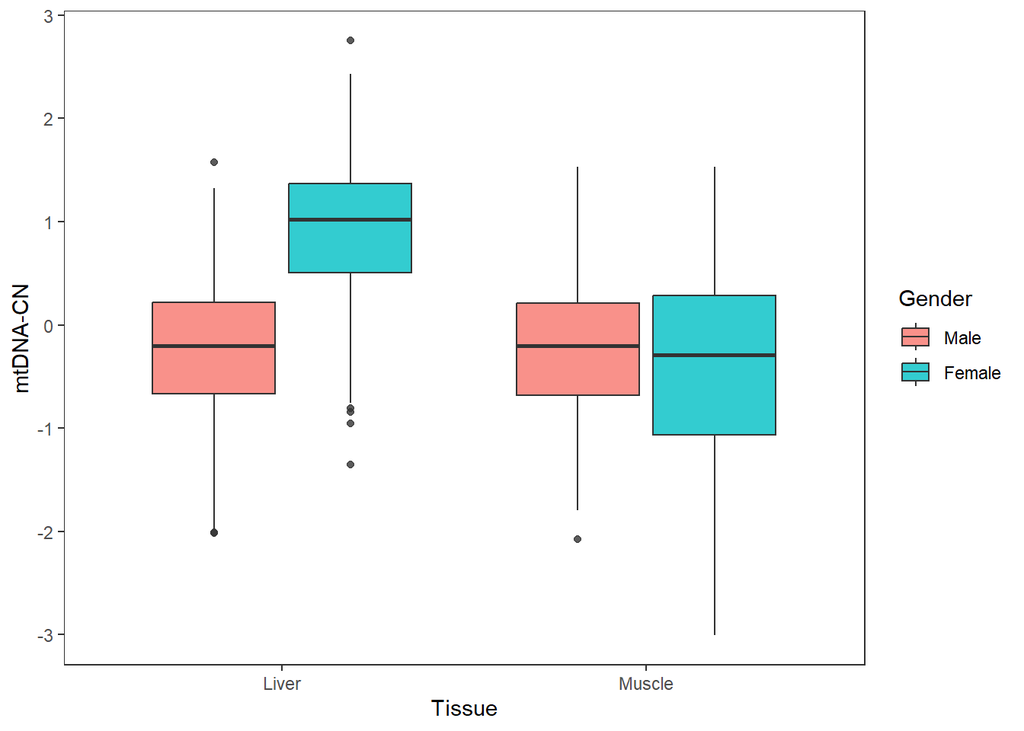

```r
# Faceted box plots by group and gender
ggplot(data = data, aes(x = Group)) +
  geom_boxplot(alpha=0.8, aes(y=mtDNA_CN_INT_residual, fill=factor(Gender))) +
  theme_bw() +
  theme(panel.grid.major = element_blank(),panel.grid.minor = element_blank()) +
  xlab("Tissue") + ylab("mtDNA-CN") + labs(fill = "Gender") + scale_fill_discrete(labels=c("Male","Female"))
```

```r
# Relationship between age and mtDNA-CN,some possible nonlinear relationships were observed.
model <- lm(mtDNA_CN_INT_residual ~ Age,data=data)
# Age had a strong effect on mtDNA-CN, explaining the greater mtDNA-CN variance
summary(model)
```

```
##
## Call:
## lm(formula = mtDNA_CN_INT_residual ~ Age, data = data)
##
## Residuals:
##      Min       1Q   Median       3Q      Max
## -2.66700 -0.55352 -0.09272  0.49275  2.73398
##
## Coefficients:
##               Estimate Std. Error t value Pr(>|t|)
## (Intercept)  1.2808040  0.0510733   25.08   <2e-16 ***
## Age         -0.0265632  0.0009938  -26.73   <2e-16 ***
## ---
## Signif. codes:  0 '***' 0.001 '**' 0.01 '*' 0.05 '.' 0.1 ' ' 1
##
## Residual standard error: 0.7892 on 1991 degrees of freedom
## Multiple R-squared:  0.2641, Adjusted R-squared:  0.2637
## F-statistic: 714.5 on 1 and 1991 DF,  p-value: < 2.2e-16
```

```r
# Looking for knots
suppressPackageStartupMessages(library(earth))
suppressPackageStartupMessages(library(splines))
mars_model <- earth(mtDNA_CN_INT_residual ~ Age, data=data)
# The possible knot is 54
summary(mars_model)
```

```
## Call: earth(formula=mtDNA_CN_INT_residual~Age, data=data)
##
##             coefficients
## (Intercept)  0.269027184
## h(54-Age)    0.004758738
## h(Age-54)   -0.062820986
##
## Selected 3 of 4 terms, and 1 of 1 predictors
## Termination condition: RSq changed by less than 0.001 at 4 terms
## Importance: Age
## Number of terms at each degree of interaction: 1 2 (additive model)
## GCV 0.5623962    RSS 1115.239    GRSq 0.3355817    RSq 0.3382473
```

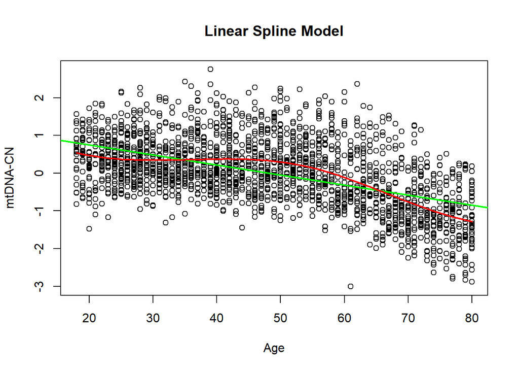

```r
spline_model <- lm(mtDNA_CN_INT_residual ~ bs(Age, knots=54), data=data)
# Obtaining predicted mtDNA
predict_cn<- predict(spline_model,list(Age=sort(data$Age)),se=T)
# Scatter plot and fitted lines
plot(data$Age, data$mtDNA_CN_INT_residual, main="Linear Spline Model", xlab="Age", ylab="mtDNA-CN")
# Liner mode
abline(model, col="green", lwd=2)
# Linear Spline Model
lines(sort(data$Age), predict_cn$fit, col="red",lwd=2)
```

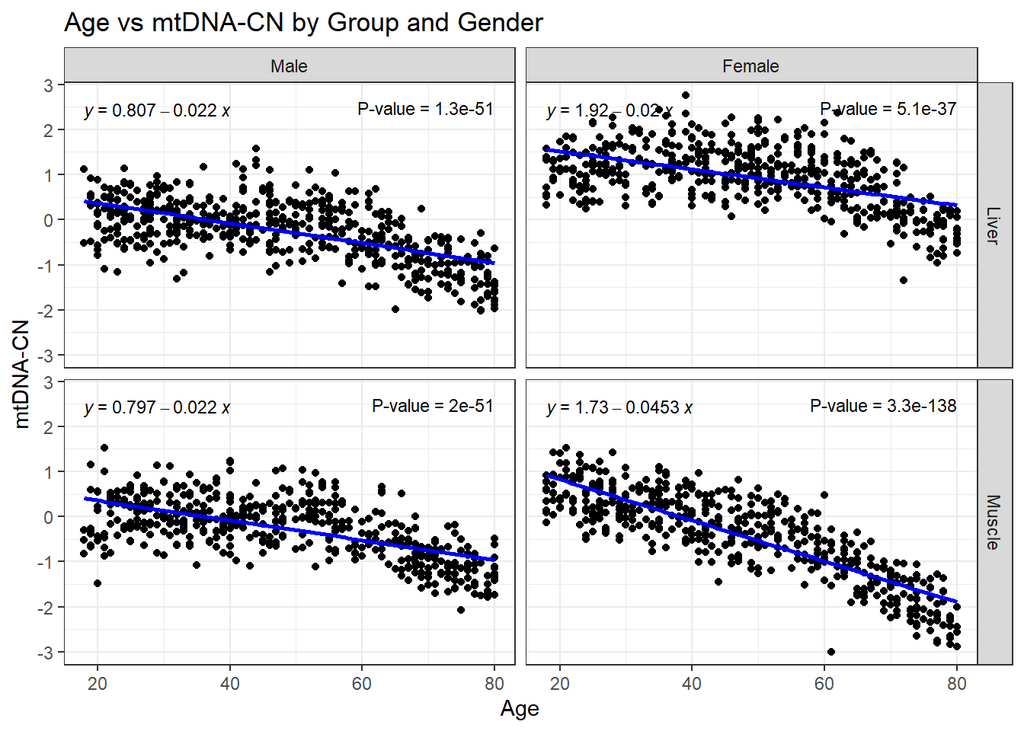

```r
suppressPackageStartupMessages(library(ggpmisc))
data$Gender <- factor(data$Gender, levels = c(1, 2), labels = c("Male", "Female"))
ggplot(data, aes(x = Age, y = mtDNA_CN_INT_residual)) +
  geom_point() +
  theme_bw() +
  geom_smooth(method = "lm",formula = y~x, se = FALSE, color = "blue") +
  facet_grid(Group ~ Gender) +
  stat_poly_eq(aes(label = paste(after_stat(eq.label),sep = "~~~")), formula = y~x, parse = TRUE,size = 3)  +
  stat_fit_glance(method = 'lm',method.args = list(formula = y ~ x), geom = 'text',aes(label = paste("P-value = ", signif(after_stat(p.value), digits = 2), sep = "")), label.x.npc = 'right', size = 3) +
  labs(title = "Age vs mtDNA-CN by Group and Gender",y = "mtDNA-CN")
```

# 5.Conclusions

From the analysis of the simulated data, we observe that: 1. Mean mtDNA-CN was significantly higher in females than in males, highlighting women may have a greater need for energy. 2. Mean mtDNA-CN in liver tissue is considerably higher than in muscle tissue, potentially indicating varying mtDNA copy number requirements across different types of tissues. 3. mtDNA-CN showed a decreasing trend with age throughout the sample. Notably, mtDNA-CN declined more rapidly after age 54, suggesting a concern for the body’s energy metabolism. 4. The age effect was greater in Muscle in females, and changes in mtDNA-CN were more significantly with age, indicating that both age and gender may collaboratively affect mtDNA-CN levels, especially in specific tissue types.